# Determinantes de Niveles de Obesidad en Paises de Latinoamérica 2019

Diego Alzate, Juliana Fiquitiva , Estefania Silva

2024-03-03

### **Introducción**

Desde 1975, la obesidad casi se ha triplicado en todo el mundo. En 2016, más de 1.900 millones de adultos mayores de 18 años tenían sobrepeso y más de 650 millones de ellos eran obesos.Según (World Health Organization: WHO, 2024) “El sobrepeso y la obesidad se definen como una acumulación anormal o excesiva de grasa que puede ser perjudicial para la salud.”El incremento en el consumo de alimentos procesados, se ha convertido en una de las principales causas de la obesidad. La grasa y el azúcar son una parte importante de la dieta actual y contribuyen a este problema. Otro problema adicional es el sedentarismo asociado a la urbanización.

El sobrepeso y la obesidad son un problema multifactorial y resultan de una combinación compleja de factores económicos, genéticos, sociales y ambientales. Elementos como la historia familiar son indicativos de que el sobrepeso y la obesidad pueden transmitirse de generación en generación, la edad y el género nos revela que tanto adultos,niños, hombres y mujeres enfrentan desafíos específicos. Los hábitos alimenticios y de actividad física junto con patrones familiares y culturales ejercen una influencia directa en el peso de un individuo. La interacción de estos elementos complica la pérdida de peso y aumenta la propensión a la obesidad. Abordar este problema requiere una comprensión de estos factores para implementar estrategias efectivas en la prevención y tratamiento.

A nivel global, la obesidad representa un desafío significativo para los sistemas de salud pública, La creciente prevalencia de esta condición no sólo conlleva riesgos directos para la salud individual, sino que también ejerce una presión significativa sobre los recursos médicos y las estructuras de atención sanitaria a nivel global. La necesidad de un enfoque general se manifiesta en la comprensión de que la obesidad es un problema complejo que no puede ser resuelto exclusivamente a nivel individual. Considerar las dimensiones socioeconómicas implica abordar las inequidades en el acceso a recursos y oportunidades que contribuyen a estilos de vida saludables. Además, la influencia del entorno ambiental, que abarca desde la disponibilidad de alimentos nutritivos hasta la accesibilidad de espacios para la actividad física, destaca la importancia de medidas políticas y comunitarias.

En Latinoamérica es común frecuentar restaurantes de comida rápida, la compra de gaseosas, paquetes y alimentos ricos en grasa.Esto se debe a su fácil accesibilidad, y la mayoría de veces, esta opción se usa para satisfacer las necesidades alimentarias diarias. (Julio Berdegué, 2019) afirma que “El explosivo aumento de la obesidad que afecta al 24% de la población regional, unos 105 millones de personas, prácticamente el doble del nivel global de 13,2%”. Los efectos de estas decisiones influyen en el futuro cuando las personas tienen enfermedades asociadas con el sobrepeso y obesidad; o cuando finalmente mueren debido a esta situación, esto se afirma en el documento panorama de la seguridad alimentaria y nutricional en América Latina y el Caribe para el año 2019 (FAO, OPS, WFP y UNICEF. 2019) “600.000 personas mueren cada año en América Latina y el Caribe por enfermedades relacionadas con la mala alimentación, como diabetes, hipertensión arterial y enfermedades cardíacas.”

Dado el panorama de hábitos de consumo alimenticios en América Latina y el caribe según la FAO (Organización para las Naciones Unidas para la Alimentación y la Agricultura, 2019) Existe una oferta agregada de alimentos suficientes para toda la población en América Latina y el Caribe, sin embargo la presencia de desigualdad y pobreza inciden en la distribución de esta oferta alimentaria generando grupos poblacionales con poco acceso a alimentos, lo que conlleva a condiciones crónicas de desnutrición y enfermedades asociadas a este. Por otra parte el azúcar, las grasas y los aceites son los tres elementos de mayor consumo en la región, donde el 14.2% como la proporción de energia proviene del azúcar, siendo esta mayor al 10% de proporción de energia recomendada que provee este grupo alimentacio segun la Organización Mundial de la Salud.

Ahora como factores estructurales, existen fenómenos llamados Desiertos y Pántanos Alimentarios, en primera medida se asocia a la ausencia de alimentos y la lejanía geográfica respecto a las fuentes de acceso de alimentos, por otra parte los pántanos alimentarios reflejan una alta proporción en la oferta de alimentos, de alimentos ultraprocesados respecto a los alimentos altos en proteinas, grasas saludables y micronutrientes, lo que genera un precio relativo menor en los alimentos ultraprocesados respecto a los alimentos de alta calidad alimentaria, incentivando una demanda mayor de alimentos de baja calidad repercutiendo a largo plazo en la salud de las personas que son mas sensibles a variaciones del precio especialmente las personas de bajo poder adquisitivo, presionando a largo plazo el gasto público en salud por enfermedades prevenibles como Diabetes, Obesidad e Hipertensión entre otras.

### **Variables:**

- Consumo frecuente de alimentos con altas calorías: Variable cualitativa que clasifica en si y no, si el individuo consume frecuentemente alimentos procesados como salchichas, tocino, jamón, alimentos fritos y lácteos.
- Frecuencia de consumo de verduras o vegetales: Variable numérica de 1 a 3, que indica el número de porciones que se consume por día de verduras y vegetales; La OMS recomienda comer unos 400 gramos de fruta y verduras al día, lo que resulta muy útil para prevenir enfermedades crónicas como enfermedades cardiacas, cáncer, diabetes tipo 2 y obesidad.
- Número de comidas principales: Variable numérica de 1 a 4, que indica el número de comidas que el individuo consume como comida principal (Se define comida principal como una comida alta en nutrientes, carbohidratos y proteina)
- Consumo de agua diario: Variable numérica de 1 a 3, que indica la cantidad de litros de agua que consume al día el individuo; Se recomienda la ingesta de agua (de todas las fuentes) 3.0 litros para los hombres y 2,7 litros por día para las mujeres para mantener una correcta hidratación.
- Consumo de alcohol: Variable categórica que clasifica la frecuencia en que el individuo consume alcohol, clasificándolo en No, algunas veces, frecuentemente y siempre. Según estudios el abuso de alcohol ocasiona una carga de morbilidad y tiene importantes consecuencias sociales y económicas.

Las variables relacionadas con la condición física son:

- Frecuencia de actividad física: Variable numérica de 0 a 3 que indica la cantidad de horas al día que el individuo practica actividad física; Según la OMS, Latinoamérica es la región del mundo con el mayor porcentaje de población con una actividad física insuficiente, alcanzando el 39%.
- Tiempo de uso de dispositivos tecnológicos: Variable numérica que indica la cantidad de horas al día que el individuo dispone para uso de tecnología; Colombia ocupa el segundo lugar en el mundo en el tiempo en el que los ciudadanos dedican a las redes sociales según la Organización para la Cooperación y el Desarrollo Económico(OCDE).
- Transporte utilizado: Variable cualitativa que clasifica el medio de transporte que usa la persona diariamente, clasificándolo en automóvil, bicicleta, moto, transporte público y caminando.

### **OBJETIVOS:**

**Objetivo General**

- Determinar los factores de riesgo con mayor incidencia en la obesidad y sobrepeso para los paises de Colombia, Perú y México así como describirlos y encontrar relaciones entre estos.

**Objetivos Específicos:**

- Modelar el peso en su espectro completo a través del IMC ver si existen cambios respecto al enfoque con variable respuesta cualitativa.
- Determinar los factores de riesgo más significativos como predictores de la obesidad y sobrepeso.
- Usar métodos de regularización para generar estimaciones en muestras nuevas respecto a la clasificación de peso normal y obesidad dadas las variables predictoras a través del uso de Modelos Lineales Generalizados.

```r
obesidad<-read.csv("ObesityDataSet.csv")
obesidad<-data.frame(obesidad)
sum(is.na(obesidad))
```

```
## [1] 0
```

- Al observar que no se encuentran datos faltantes se procede a realizar un análisis descriptivo y exploratorio de los datos.

```
## [1] 2111   17
```

- Se observan 8 variables cuantitativas las cuales son edad(14-61), estatura(1.45-1.98), peso(39-173), frecuencia de consumo de vegetales(1-3), número de comidas principales(1-4), consumo de agua diaria(1-3), frecuencia de actividad física(0-3 veces por semana) y tiempo de uso de la tecnologia(0-2).Las 9 variables restantes son cualitativas: género(Female, Male), antecedentes familiares(yes, no), frecuencia de consumo de altas calorias(yes, no), consumo de meriendas(no, Sometimes, Frequently, Always), fumador(yes,no), monitoreo de calorias(yes, no), consumo de alcohol(no, Sometimes, Frequently, Always), medio de transporte(Automobile,Bike, Motorbike, Public_Transportation, Walking) y clasificación de obesidad(Insufficient_Weight, Normal_Weight, Obesity_Type_I, Obesity_Type_II, Obesity_Type_III, Overweight_Level_I, Overweight_Level_II).

```r
#Reasignar variable de sobrepeso
obesidad_f <- obesidad_f %>%
  mutate(tipo_peso = case_when(
    clasificacion_obesidad %in% c("Insufficient_Weight")~ 0,
    clasificacion_obesidad %in%    c("Normal_Weight") ~ 1,
    clasificacion_obesidad %in%    c("Obesity_Type_I","Obesity_Type_II"
                                     ,"Obesity_Type_III") ~ 2,
    clasificacion_obesidad %in% c("Overweight_Level_I",
                                  "Overweight_Level_II") ~ 3) )
#
obesidad_f$tipo_peso <- factor(obesidad_f$tipo_peso)
```

### Gráfico 1: Distribución y Coeficientes de Correlación de las Variables Cuantitativas:

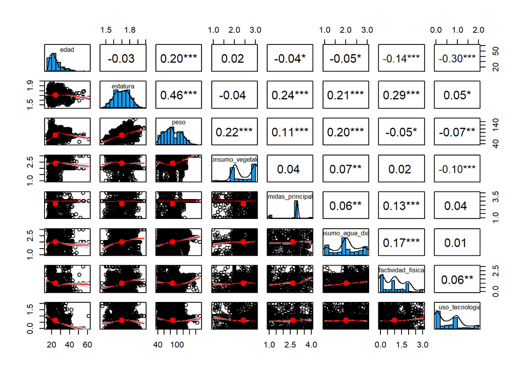

```
##       edad          estatura          peso        fconsumo_vegetales
##  Min.   :14.00   Min.   :1.450   Min.   : 39.00   Min.   :1.000
##  1st Qu.:19.95   1st Qu.:1.630   1st Qu.: 65.47   1st Qu.:2.000
##  Median :22.78   Median :1.700   Median : 83.00   Median :2.386
##  Mean   :24.31   Mean   :1.702   Mean   : 86.59   Mean   :2.419
##  3rd Qu.:26.00   3rd Qu.:1.768   3rd Qu.:107.43   3rd Qu.:3.000
##  Max.   :61.00   Max.   :1.980   Max.   :173.00   Max.   :3.000
##  comidas_principales consumo_agua_diaria factividad_fisica t_uso_tecnologia
##  Min.   :1.000       Min.   :1.000       Min.   :0.0000    Min.   :0.0000
##  1st Qu.:2.659       1st Qu.:1.585       1st Qu.:0.1245    1st Qu.:0.0000
##  Median :3.000       Median :2.000       Median :1.0000    Median :0.6253
##  Mean   :2.686       Mean   :2.008       Mean   :1.0103    Mean   :0.6579
##  3rd Qu.:3.000       3rd Qu.:2.477       3rd Qu.:1.6667    3rd Qu.:1.0000
##  Max.   :4.000       Max.   :3.000       Max.   :3.0000    Max.   :2.0000
```

- La persona más joven en la encuesta tiene 14 años y la persona más vieja tiene 61 años, por otra parte el 50% de los encuestados tienen menos de 22 y el 75% tiene 26 años o menos, lo que nos dice que hay una alta concentración de adolescentes y adultos jóvenes en proporción a la población vieja.
- La estatura promedio en los encuestados es de 1.70 metros, donde la persona más baja mide 1.45 metros y la persona más alta 1.98 metros, por otra parte el 50% de las personas más bajas miden 1.70 metros o menos.
- Respecto al peso, la persona con menor peso tiene 39kg de peso y la persona con mayor peso tiene 173 kg. El 50% de las personas pesan 83 kg o menos, donde si comparamos esta medida de peso mediana con la altura mediana observamos que existen indicios de sobrepeso y obesidad en la muestra dada la proporcion asociada al IMC (Indice de Masa Corporal).
- Dentro de la frecuencia diaria de consumo de vegetales(cantidad de porciones al día), tenemos que las personas con menor consumo de vegetales, solamente ingieren una porción de frutas o verduras al día, mientras que las personas que mayor nivel de consumo de vegetales tienen, ingieren 3 porciones diarias. La Organización Mundial de la Salud aconseja el consumo de 5 porciones diarias de frutas y/o vegetales para prevenir enfermedades asociadas a los hábitos de vida, en este orden de ideas podemos observar que el total de encuestados tienen un consumo diario de vegetales deficiente.
- En la frecuencia diaria de consumo de comidas principales(cantidad de comidas principales al dia), las personas con menor frecuencia consumen una comida principal al día, mientras que aquellas con mayor frecuencia consumen 4 comidas principales al día, donde el promedio de personas consumen 3 comidas y el 50% de personas consumen 3 comidas o menos al día igual que el 75% de las personas en la encuesta. La Organización Mundial de la salud recomienda el consumo de 3 comidas principales día (Desayuno, Almuerzo, Cena) donde estas se caracterizan por tener alto contenido de macronutrientes y micronutrientes. En general para los encuestados su frecuencia diaria de consumo de comidas principales es buena, respecto a las necesidades nutricionales diarias para mantener una buena salud.
- La cantidad de litros diarios de agua bebidos, tenemos que las personas con menor consumo de agua beben 1 Litro al día, mientras que las personas con mayor consumo diario beben 3 Litros. En promedio los encuestados beben 2 litros al igual que el 50% de los individuos de la muestra, según la OMS la recomendación diaria es de 2.0 a 2.5 litros para mujeres y hombres respectivamente, en ese orden de ideas, los encuestados tienen un comportamiento relativamente saludable respecto a la cantidad de litros de agua que beben al día.
- Dentro de la frecuencia semanal de actividad física, hay individuos que no se ejercitan ni un día a la semana, mientras que los más atléticos de la muestra se ejercitan 3 veces a la semana. En promedio los individuos se ejercitan solo una vez a la semana y el 70% de los que menos se ejercitan lo hacen 1.6 veces por semana. Según la OMS se recomienda realizar actividad física moderada por lo menos 2 veces a la semana, por lo que en la muestra los encuentados el 70% tienen niveles insuficientes de ejercicio semanal.
- Dentro de los hábtios de consumo de tecnología, hay individuos que no usan tecnología en absoluto mientras que los que mayor uso le dan a esta, dedican 2 horas diarias en ella. En promedio se dedican 0.65 horas diarias de consumo de tecnología, donde el 50% de individuos que menor uso le dan dedican 0.62 horas díarias o menos. Dentro de los parámetros de Salud la OMS recomienda dar un uso moderado diario de tecnología, donde se considera normal el uso mientras tanto no interfiera en las actividades diarias de una persona, como la alimentación, el descanso, el trabajo y estudio etc. A partir de sobrepasar estas barreras su uso se consideraria patológico.
- Se evidencia qué existe una correlacion positiva media 0.46 entre estatura y peso, esto se debe al IMC, el cuál sirve para la categorización del peso: bajo peso, peso saludable, sobrepeso y obesidad.
- Se observa qué la estatura y la actividad fisica están correlacionadas positivamente de forma débil 0.29 , la actividad física moderada ayuda a desarrollar los músculos y huesos.
- Respecto a comidas principales y estatura existe una correlacion positiva débil 0.24, los alimentos son necesarios para el crecimiento y desarrollo, especialmente en edades escolares. Un análisis realizado por la revista Lancet (2019) afirma qué la alimentación deficiente en los niños de edad escolar puede contribuir a una diferencia promedio de 20 cm en la altura entre los individuos de diferentes países.
- Existe una correlación negativa débil entre edad y uso tecnológico de -0.30 ,es decir cuando la edad aumenta el uso de la tecnología tiende a disminuir.

### Gráfico 2: Frecuencia de Actividad Física por Género

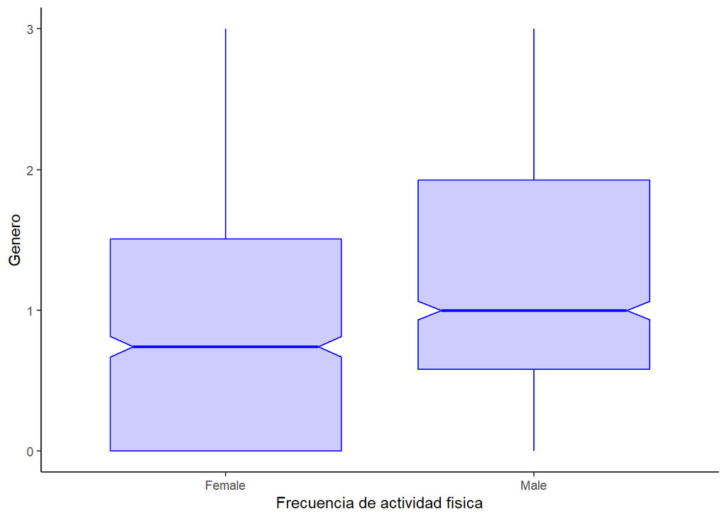

### Gráfico 3: Frecuencia de Consumo de Alcohol y Peso

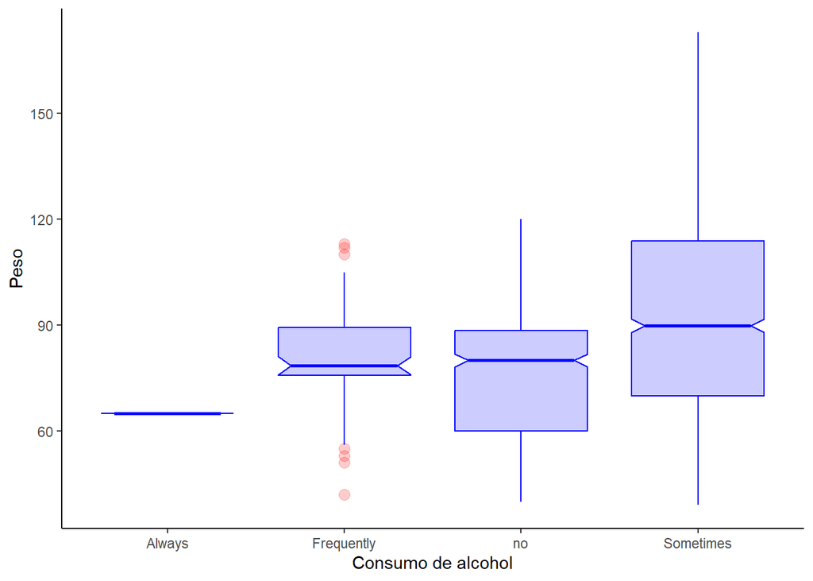

- Se puede observar en el **Gráfico 3** que las medianas de los individuos que consumen alcohol siempre y a veces son distintas, es decir el peso de los que siempre consumen alcohol tiende a ser constante mientras que los que consumen a veces tienen el mayor rango de peso aproximadamente desde 39kg hasta por encima de 100 kg representando esto una alta dispersión, existen valores atípicos en el peso de los que consumen frecuentemente alcohol, es decir individuos con pesos atipicamente bajos y atipicamente altos. Manteniendo todo constante el alcohol parece no tener un impacto significativo en el peso.

### Gráfico 4: Distribución de los Fumadores por Edad

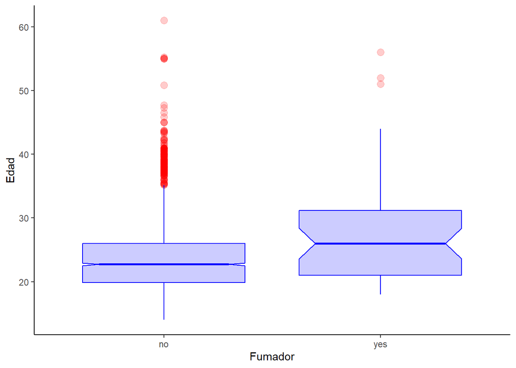

Intuitivamente tenemos que la edad de no fumadores se centra entre los 20 a 25 años aproximadamente, existiendo valores atípicos donde individuos por encima de los 30 años no son fumadores, mientras que el rango de edad de fumadores en un 50% se centra entre los 22 a 32 años, y es común que personas de más de 30 años sean fumadores.

### Gráfico 5: Distribución del Peso corporal según la presencia de antecedentes familiares de Obesidad

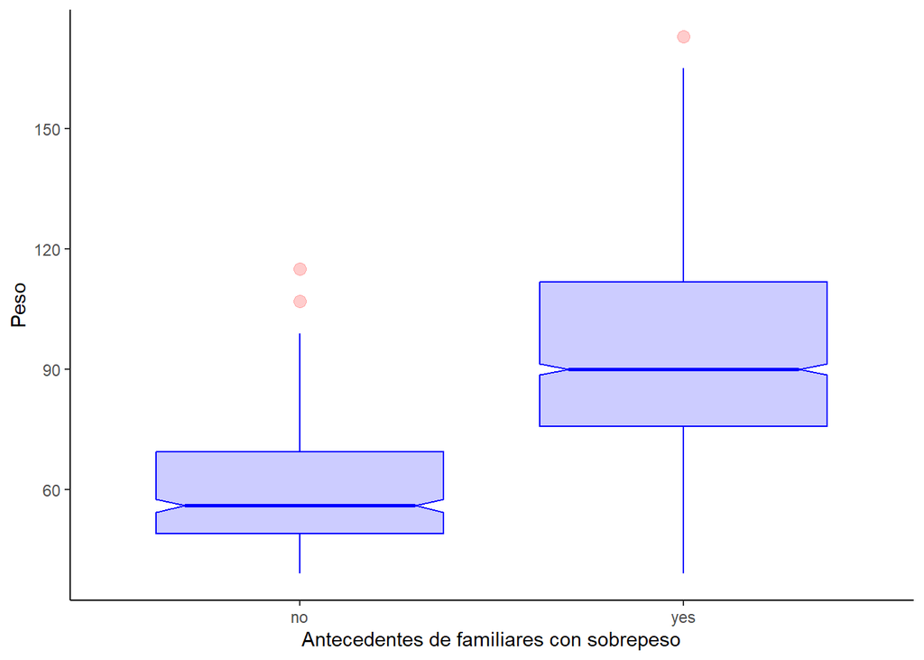

### Gráfico 7: Frecuencia de Uso de Distintos Medios de Transporte

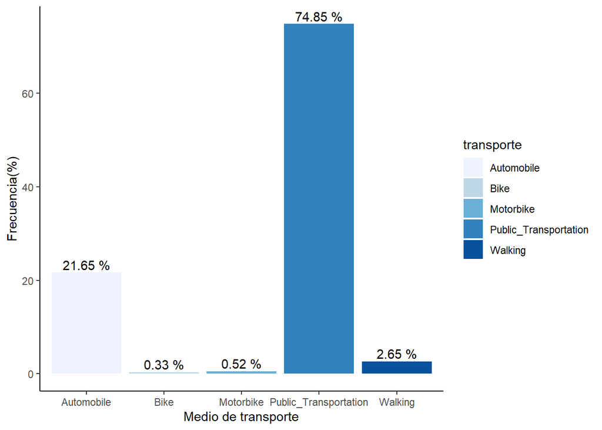

### Tabla 2: Frecuencia (%) de Uso de Medios de Transporte

Uso porcentual de medios de transporte

| transporte | frecuencia |
| --- | --- |
| Automobile | 21.65 |
| Bike | 0.33 |
| Motorbike | 0.52 |
| Public_Transportation | 74.85 |
| Walking | 2.65 |

### Gráfico 8: Frecuencia de Consumo de Alimentos con Altas Calorias por Edad:

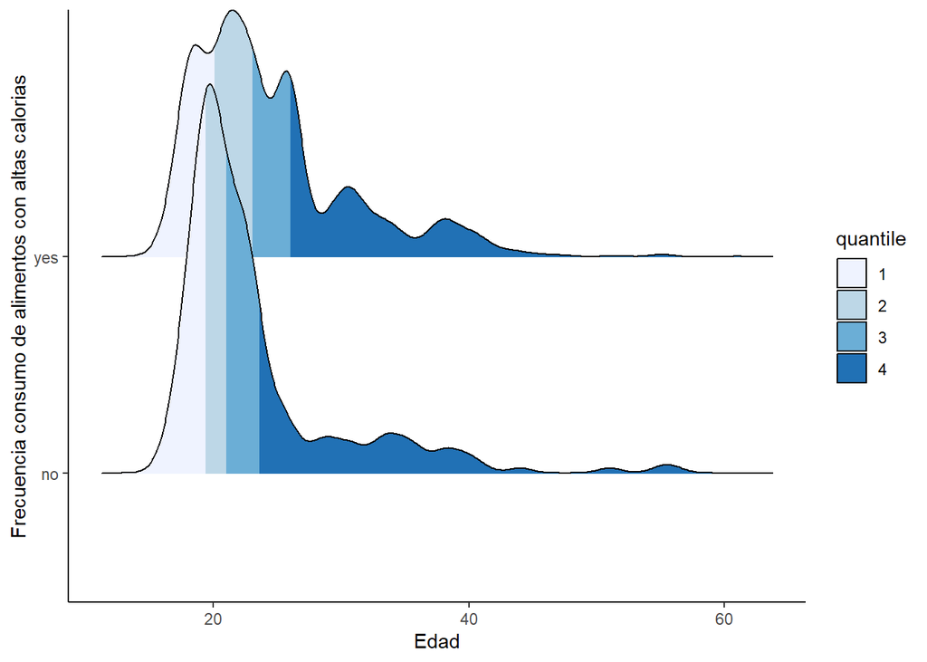

- Podemos observar en el **Gráfico: 8** que las personas con baja frecuencia de consumo de alimentos con altas calorías se concentran entre los 20 y 25 años aproximadamente, mientras que las personas que si consumen frecuente alimentos con altas calorías tienen edades entre los 18 a 25 años aproximadamente. El 75% de las personas que menos consumen alimentos altos en calorías tienen edades de 25 años o menos mientras que el 75% de personas que no consumen alimentos altos en calorías tienen 22 años o menos. A nivel general esto nos muestra que los grupos etarios más viejos consumen menos alimentos con alto contenido calórico dentro de ambas categorias, es decir aquellos que si lo hacen lo hacen en menor proprción que los grupos jóvenes. Por otra parte respecto a los que consumen y no alimentos de altas calorías, no hay una diferencia etaria es decir grupos de mismas edades en proporciones similares consumen y no alimentos altos en calorias, lo que nos sugiere que factores exógenos como los niveles de ingreso de los individuos y factores estructurales como los precios relativos más altos de alimentos saludables respecto a los alimentos ultraprocesados son factores que inciden en la elección de la dieta en grupos de edad, por ejemplo personas o grupos familiares con elasticidades precio de la demanda más altas respecto a los alimentos ultraprocesados se ven forzados a consumirlos dado su poder adquisitivo que grupos familiares o individuos con poder adquisitivo que tienen una elasticidad precio de la demanda menor en el mercado de alimentos y por ende ante cambios de los precios relativos de alimentos ultraprocesados y alimentos de alta calidad nutricional siguen teniendo la capacidad de elegir.

### Gráfico 9: Frecuencia de Consumo de Alimentos Altos en Calorias y Peso de los Individuos:

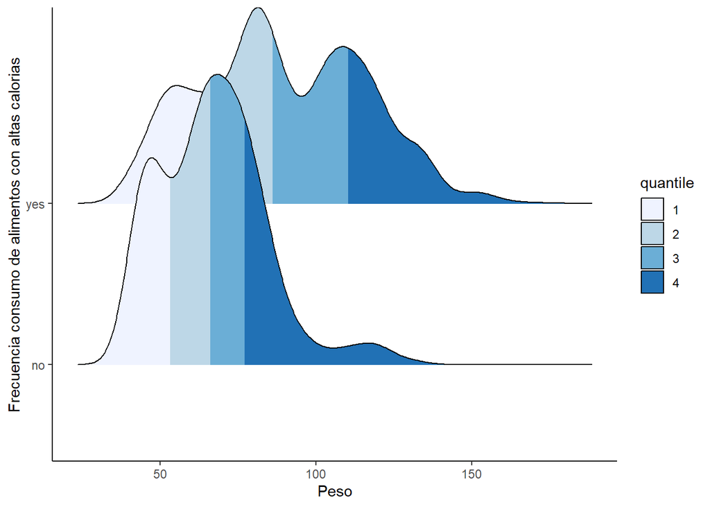

- Podemos observar en el **Gráfico 9** que dentro de las personas que no consumen alimentos altos en calorías su peso se concentra en 50 kg y 60kg aproximadamente mostrando un comportamiento bimodal con una asimetria relativamente positiva, es decir que aquellos que no consumen alimentos altos en calorias tienen un peso corporal bajo, ahora por otra parte las personas que consumen alimentos altos en calorias tienen valores de pesos concentrados en aproximadamente 60kg, 80 kg y más de 100kg es decir un comportamiento aproximadamente trimodal con mayor apuntamiento en los 80kg. Esto nos sugiere que el consumo de alimentos altos en calorías incide de forma positiva en el peso corporal de una persona, pues el 15% de los individuos más pesados de los que no consumen esta clase de alimentos es menor al 15% de los individuos más pesados que si lo hacen efectivamente.

### MODELO 1:

```
##
## Call:
## lm(formula = log(peso) ~ ., data = obesidad_norm[, -c(17, 18)])
##
## Residuals:
##      Min       1Q   Median       3Q      Max
## -0.70107 -0.12566  0.02292  0.12735  0.72551
##
## Coefficients:
##                                         Estimate Std. Error t value Pr(>|t|)
## (Intercept)                            1.2602544  0.2307706   5.461 5.30e-08
## generoMale                            -0.0163217  0.0120128  -1.359 0.174391
## edad                                   0.0126337  0.0009396  13.447  < 2e-16
## estatura                               1.3414765  0.0689999  19.442  < 2e-16
## antecedentes_familiares_sobrepesoyes   0.2481835  0.0129232  19.205  < 2e-16
## fconsumo_altas_caloriasyes             0.0559569  0.0147524   3.793 0.000153
## fconsumo_vegetales                     0.0928148  0.0087216  10.642  < 2e-16
## comidas_principales                    0.0021911  0.0058940   0.372 0.710113
## nmeriendasFrequently                  -0.1432453  0.0304398  -4.706 2.69e-06
## nmeriendasno                           0.1054074  0.0405209   2.601 0.009353
## nmeriendasSometimes                    0.1152908  0.0281872   4.090 4.47e-05
## fumadoryes                            -0.0190969  0.0308834  -0.618 0.536410
## consumo_agua_diaria                    0.0217098  0.0075894   2.861 0.004271
## monitoreo_caloriasyes                 -0.0569394  0.0218057  -2.611 0.009087
## factividad_fisica                     -0.0335087  0.0056529  -5.928 3.59e-09
## t_uso_tecnologia                      -0.0215450  0.0077123  -2.794 0.005260
## consumo_alcoholFrequently             -0.1086972  0.2025469  -0.537 0.591565
## consumo_alcoholno                     -0.1591921  0.2012841  -0.791 0.429102
## consumo_alcoholSometimes              -0.0916584  0.2014424  -0.455 0.649149
## medio_transporteBike                   0.0638741  0.0763313   0.837 0.402800
## medio_transporteMotorbike              0.1663344  0.0613524   2.711 0.006760
## medio_transportePublic_Transportation  0.1641969  0.0136775  12.005  < 2e-16
## medio_transporteWalking                0.0690998  0.0301593   2.291 0.022053
##
## (Intercept)                           ***
## generoMale
## edad                                  ***
## estatura                              ***
## antecedentes_familiares_sobrepesoyes  ***
## fconsumo_altas_caloriasyes            ***
```

[output cut: 8 more lines]

```
## factividad_fisica                     ***
## t_uso_tecnologia                      **
## consumo_alcoholFrequently
## consumo_alcoholno
## consumo_alcoholSometimes
## medio_transporteBike
## medio_transporteMotorbike             **
## medio_transportePublic_Transportation ***
## medio_transporteWalking               *
## ---
## Signif. codes:  0 '***' 0.001 '**' 0.01 '*' 0.05 '.' 0.1 ' ' 1
##
## Residual standard error: 0.1983 on 2088 degrees of freedom
## Multiple R-squared:  0.6107, Adjusted R-squared:  0.6066
## F-statistic: 148.9 on 22 and 2088 DF,  p-value: < 2.2e-16
```

### Modelo que Minimiza el AIC (Criterio de Información de Akaike):

```
##
## Call:
## lm(formula = log(peso) ~ edad + estatura + antecedentes_familiares_sobrepeso +
##     fconsumo_altas_calorias + fconsumo_vegetales + nmeriendas +
##     consumo_agua_diaria + monitoreo_calorias + factividad_fisica +
##     t_uso_tecnologia + consumo_alcohol + medio_transporte, data = obesidad_norm[,
##     -c(17, 18)])
##
## Residuals:
##      Min       1Q   Median       3Q      Max
## -0.71352 -0.12478  0.02309  0.12472  0.70397
##
## Coefficients:
##                                         Estimate Std. Error t value Pr(>|t|)
## (Intercept)                            1.3318724  0.2245232   5.932 3.49e-09
## edad                                   0.0124797  0.0009296  13.425  < 2e-16
## estatura                               1.2860309  0.0536125  23.988  < 2e-16
## antecedentes_familiares_sobrepesoyes   0.2492360  0.0128867  19.341  < 2e-16
## fconsumo_altas_caloriasyes             0.0573359  0.0146865   3.904 9.76e-05
## fconsumo_vegetales                     0.0962448  0.0083541  11.521  < 2e-16
## nmeriendasFrequently                  -0.1413174  0.0304110  -4.647 3.58e-06
## nmeriendasno                           0.0985440  0.0401121   2.457  0.01410
## nmeriendasSometimes                    0.1157688  0.0281518   4.112 4.07e-05
## consumo_agua_diaria                    0.0222738  0.0075735   2.941  0.00331
## monitoreo_caloriasyes                 -0.0569957  0.0217682  -2.618  0.00890
## factividad_fisica                     -0.0333298  0.0056404  -5.909 4.01e-09
## t_uso_tecnologia                      -0.0216557  0.0076978  -2.813  0.00495
## consumo_alcoholFrequently             -0.0984010  0.2021720  -0.487  0.62651
## consumo_alcoholno                     -0.1486993  0.2009387  -0.740  0.45937
## consumo_alcoholSometimes              -0.0793532  0.2010040  -0.395  0.69304
## medio_transporteBike                   0.0610416  0.0762877   0.800  0.42372
## medio_transporteMotorbike              0.1597086  0.0611905   2.610  0.00912
## medio_transportePublic_Transportation  0.1642109  0.0135708  12.100  < 2e-16
## medio_transporteWalking                0.0685375  0.0301151   2.276  0.02296
##
## (Intercept)                           ***
## edad                                  ***
## estatura                              ***
## antecedentes_familiares_sobrepesoyes  ***
## fconsumo_altas_caloriasyes            ***
## fconsumo_vegetales                    ***
## nmeriendasFrequently                  ***
## nmeriendasno                          *
## nmeriendasSometimes                   ***
## consumo_agua_diaria                   **
## monitoreo_caloriasyes                 **
## factividad_fisica                     ***
## t_uso_tecnologia                      **
## consumo_alcoholFrequently
## consumo_alcoholno
## consumo_alcoholSometimes
## medio_transporteBike
## medio_transporteMotorbike             **
## medio_transportePublic_Transportation ***
## medio_transporteWalking               *
## ---
## Signif. codes:  0 '***' 0.001 '**' 0.01 '*' 0.05 '.' 0.1 ' ' 1
##
## Residual standard error: 0.1983 on 2091 degrees of freedom
## Multiple R-squared:  0.6103, Adjusted R-squared:  0.6067
## F-statistic: 172.3 on 19 and 2091 DF,  p-value: < 2.2e-16
```

**Interpretación del Modelo:**

```r
exp(modelo_final$coefficients)
```

```
##                           (Intercept)                                  edad
##                             3.7881298                             1.0125579
##                              estatura  antecedentes_familiares_sobrepesoyes
##                             3.6183963                             1.2830448
##            fconsumo_altas_caloriasyes                    fconsumo_vegetales
##                             1.0590115                             1.1010286
##                  nmeriendasFrequently                          nmeriendasno
##                             0.8682137                             1.1035629
##                   nmeriendasSometimes                   consumo_agua_diaria
##                             1.1227363                             1.0225237
##                 monitoreo_caloriasyes                     factividad_fisica
##                             0.9445981                             0.9672195
##                      t_uso_tecnologia             consumo_alcoholFrequently
##                             0.9785771                             0.9062854
##                     consumo_alcoholno              consumo_alcoholSometimes
##                             0.8618282                             0.9237136
##                  medio_transporteBike             medio_transporteMotorbike
##                             1.0629431                             1.1731689
## medio_transportePublic_Transportation               medio_transporteWalking
##                             1.1784628                             1.0709407
```

### **Supuestos del error**

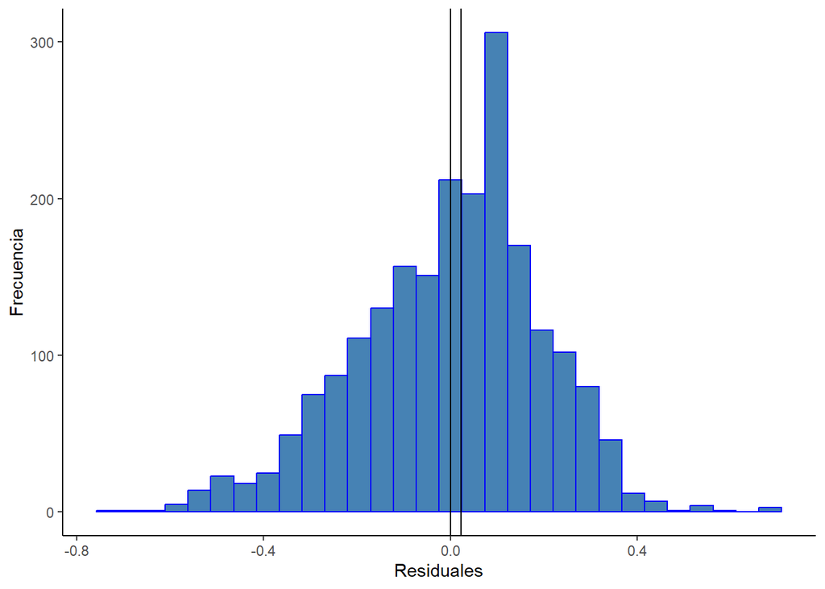

### Normalidad del Error

- **Ho: Existe normalidad**
- **Ha: No existe normalidad**

```
##
##  Shapiro-Wilk normality test
##
## data:  residuales
## W = 0.98841, p-value = 5.023e-12
```

[output not shown]

- Como se tiene una muestra grande es útil usar el test de Shapiro-Wilk, también se usará la prueba de Kolmogorov - Smirnov y se comparará con la corrección de Lilliefors.

```
##
##  Asymptotic one-sample Kolmogorov-Smirnov test
##
## data:  residuales
## D = 0.34434, p-value < 2.2e-16
## alternative hypothesis: two-sided
```

- Según el test de Kolmogorov-Smirnov p-valor < α es decir, 0.05 > 2.2e-16, se rechaza H0 es decir que no existe normalidad en los residuales del modelo con un nivel de confianza del 95%.

```
##
##  Lilliefors (Kolmogorov-Smirnov) normality test
##
## data:  residuales
## D = 0.051923, p-value = 1.941e-14
```

- Según el test de Lilliefors (Kolmogorov-Smirnov) p-valor < α es decir, 0.05 > 1.941e-14 se rechaza H0 es decir que no existe normalidad para los residuales del modelo con un nivel de confianza del 95%.

### Independencia del Error

**Prueba de Durbin Watson**

- **Ho: No hay Autocorrelación de los Residuos**
- **Ha: Autocorrelación de los Residuos**

```
##
##  Durbin-Watson test
##
## data:  modelo_final
## DW = 0.88817, p-value < 2.2e-16
## alternative hypothesis: true autocorrelation is greater than 0
```

```
##
##  Breusch-Godfrey test for serial correlation of order up to 1
##
## data:  modelo_final
## LM test = 721.02, df = 1, p-value < 2.2e-16
```

- Según el test de Durbin-Watson y Breusch-Godfrey p-valor < α ,es decir, 0.05 > 2.2e-16 se rechaza H0 es decir que existe autocorrelación en los residuales con un nivel de confianza del 95%.

### Homocedasticidad

- **Ho: Varianza del Error es constante**
- **Ha: Varianza del Error no es constante**

```
##
##  studentized Breusch-Pagan test
##
## data:  modelo_final
## BP = 194.34, df = 19, p-value < 2.2e-16
```

- El test de Breusch-Pagan indica que p-valor < α, es decir 0.05 > 2.2e-16, se rechaza H0, por tanto la varianza del error no es constante con un nivel de confianza del 95%.

### Multicolinealidad

```
##                                       GVIF Df GVIF^(1/(2*Df))
## edad                              1.867252  1        1.366474
## estatura                          1.342727  1        1.158761
## antecedentes_familiares_sobrepeso 1.329411  1        1.153001
## fconsumo_altas_calorias           1.187929  1        1.089922
## fconsumo_vegetales                1.067611  1        1.033253
## nmeriendas                        1.362260  3        1.052875
## consumo_agua_diaria               1.156367  1        1.075345
## monitoreo_calorias                1.104257  1        1.050836
## factividad_fisica                 1.235142  1        1.111370
## t_uso_tecnologia                  1.178997  1        1.085817
## consumo_alcohol                   1.202350  3        1.031190
## medio_transporte                  1.854618  4        1.080269
```

- Podemos observar que los Factores de Inflación de Varianza para todas las variables están por debajo de 5, lo que nos sugiere que no existe multicolinealidad entre las covariables del modelo.

### Modelo Generalizado

```r
# Creamos una función para hallar el Error Cuadratico Medio
MSE <- function(y, y_pred){
  n <- length(y)
  ECM <- (1/n) * sum((y-y_pred)^2)
  print(ECM)
}

# Creamos una función para hallar el R-cuadrado
R2 <- function(y, y_pred){
  y_barra <- mean(y)
  R2 <- 1 - (sum((y-y_pred)^2) / sum((y-y_barra)^2))
  print(R2)
}

# Creamos una función para el MAD
MAD <- function(y, y_pred){
  n <- length(y)
  MAD <- (1/n) *(sum(abs(y_pred - y)))
  print(MAD)
}

#Creamos una función para el MAPE
MAPE <- function(y, y_pred){
  n <- length(y)
  MAPE <- (1/n) * sum(abs((y-y_pred)/y))
}
```

```r
obesidad_f$IMC <- obesidad_f$peso/(obesidad_f$estatura^2)
obesidad_f <- filter(obesidad_f, clasificacion_obesidad !="Insufficient_Weight",
                     clasificacion_obesidad != "Normal_Weight")

# Creamos un modelo Gamma
modelo_gamma <- glm(peso ~ ., family =Gamma(link = "inverse"),
                    data =  obesidad_f[,-c(17,18,19)])
modelo_gamma <- step(modelo_gamma, trace = FALSE)

# Métricas de Error Modelo Gamma Canónico
MSE_gamma <- MSE(obesidad_f$peso,modelo_gamma$fitted.values)
```

```
## [1] 178.9221
```

```r
MAD_gamma <- MAD(obesidad_f$peso,modelo_gamma$fitted.values)
```

```
## [1] 10.72132
```

```r
MAPE_gamma <- MAPE(obesidad_f$peso,modelo_gamma$fitted.values)
```

```r
# Creamos un modelo Gamma Log
modelo_gamma_log <- glm(peso ~.,
                        family =Gamma(link = "log"),
                        data = obesidad_f[,-c(17,18,19)])
modelo_gamma_log <- step(modelo_gamma_log, trace = FALSE)

# Métricas de Error Modelo Gamma Log
MSE_gamma_log <- MSE(obesidad_f$peso,modelo_gamma_log$fitted.values)
```

```
## [1] 182.3287
```

```r
MAD_gamma_log <- MAD(obesidad_f$peso,modelo_gamma_log$fitted.values)
```

```
## [1] 10.81659
```

```r
MAPE_gamma_log <- MAPE(obesidad_f$peso,modelo_gamma_log$fitted.values)
```

```r
exp(modelo_gamma_log$coefficients)
```

```
##                           (Intercept)                            generoMale
##                             4.2044613                             0.9638925
##                                  edad                              estatura
##                             1.0019941                             4.0384491
##  antecedentes_familiares_sobrepesoyes            fconsumo_altas_caloriasyes
##                             1.1375523                             1.0913134
##                    fconsumo_vegetales                   comidas_principales
##                             1.1411809                             1.0367914
##                 monitoreo_caloriasyes                     factividad_fisica
##                             0.8817525                             0.9814135
##                     consumo_alcoholno              consumo_alcoholSometimes
##                             1.0581019                             1.0868801
##                  medio_transporteBike             medio_transporteMotorbike
##                             1.0745114                             1.1018273
## medio_transportePublic_Transportation               medio_transporteWalking
##                             1.0629405                             0.9403908
```

```r
#Normal Inverso Enlace Canónico (1/mu^2)
normal_inverso <-  glm(peso ~ .,
                        family =inverse.gaussian(link = "identity"),
                        data = obesidad_f[,-c(17,18,19)])
normal_inverso <- step(normal_inverso, trace = FALSE)

# Normal Inverso Enlace Log
normal_inverso_log <-  glm(peso ~ .,
                        family =inverse.gaussian(link = "log"),
                        data = obesidad_f[,-c(17,18,19)])
normal_inverso_log <- step(normal_inverso_log, trace = FALSE)

# Metricas de Error Normal Inverso Canónico
MSE_ni <- MSE(obesidad_f$peso,normal_inverso$fitted.values)
```

```
## [1] 193.7192
```

```r
MAD_ni <- MAD(obesidad_f$peso,normal_inverso$fitted.values)
```

```
## [1] 11.11851
```

```r
MAPE_ni <- MAPE(obesidad_f$peso,normal_inverso$fitted.values)

# Metricas de Error Normal Inverso Log
MSE_nil <- MSE(obesidad_f$peso,normal_inverso_log$fitted.values)
```

```
## [1] 186.0771
```

```r
MAD_nil <- MAD(obesidad_f$peso,normal_inverso_log$fitted.values)
```

```
## [1] 10.9186
```

```r
MAPE_nil <- MAPE(obesidad_f$peso,normal_inverso_log$fitted.values)

# Construimos un dataframe para las medidas de error de los modelos
medidas_error <- data.frame(modelo = c("Modelo Gamma", "Modelo Gamma Log",
                                       "Modelo Normal Inverso",
                                       "Modelo Normal Inverso Log"),
                            MSE = c(MSE_gamma,MSE_gamma_log,MSE_ni,MSE_nil),
                            MAD = c(MAD_gamma, MAD_gamma_log, MAD_ni, MAD_nil),
                            MAPE = c(MAPE_gamma, MAPE_gamma_log, MAPE_ni, MAPE_nil))
#
medidas_error$MSE <- round(medidas_error$MSE,4)
medidas_error$MAD <- round(medidas_error$MAD, 4)
medidas_error$MAPE <- round(medidas_error$MAPE, 4)
kable(medidas_error)
```

| modelo | MSE | MAD | MAPE |
| --- | --- | --- | --- |
| Modelo Gamma | 178.9221 | 10.7213 | 0.1129 |
| Modelo Gamma Log | 182.3287 | 10.8166 | 0.1139 |
| Modelo Normal Inverso | 193.7192 | 11.1185 | 0.1167 |
| Modelo Normal Inverso Log | 186.0771 | 10.9186 | 0.1143 |

```r
summary(modelo_gamma)
```

```
##
## Call:
## glm(formula = peso ~ genero + edad + estatura + antecedentes_familiares_sobrepeso +
##     fconsumo_altas_calorias + fconsumo_vegetales + comidas_principales +
##     consumo_agua_diaria + monitoreo_calorias + factividad_fisica +
##     consumo_alcohol + medio_transporte, family = Gamma(link = "inverse"),
##     data = obesidad_f[, -c(17, 18, 19)])
##
## Coefficients:
##                                         Estimate Std. Error t value Pr(>|t|)
## (Intercept)                            4.324e-02  9.808e-04  44.091  < 2e-16
## generoMale                             4.728e-04  9.930e-05   4.762 2.10e-06
## edad                                  -2.021e-05  8.417e-06  -2.400 0.016492
## estatura                              -1.407e-02  5.608e-04 -25.093  < 2e-16
## antecedentes_familiares_sobrepesoyes  -1.634e-03  1.875e-04  -8.714  < 2e-16
## fconsumo_altas_caloriasyes            -1.089e-03  1.682e-04  -6.471 1.31e-10
## fconsumo_vegetales                    -1.423e-03  7.954e-05 -17.895  < 2e-16
## comidas_principales                   -4.357e-04  5.541e-05  -7.862 7.05e-15
## consumo_agua_diaria                   -8.487e-05  5.998e-05  -1.415 0.157248
## monitoreo_caloriasyes                  1.766e-03  3.021e-04   5.845 6.19e-09
## factividad_fisica                      1.855e-04  4.962e-05   3.738 0.000192
## consumo_alcoholno                     -7.541e-04  2.335e-04  -3.229 0.001267
## consumo_alcoholSometimes              -9.793e-04  2.238e-04  -4.377 1.29e-05
## medio_transporteBike                  -9.376e-04  8.706e-04  -1.077 0.281669
## medio_transporteMotorbike             -1.157e-03  7.149e-04  -1.619 0.105730
## medio_transportePublic_Transportation -5.679e-04  1.248e-04  -4.551 5.76e-06
## medio_transporteWalking                8.158e-04  3.767e-04   2.166 0.030482
##
## (Intercept)                           ***
## generoMale                            ***
## edad                                  *
## estatura                              ***
## antecedentes_familiares_sobrepesoyes  ***
## fconsumo_altas_caloriasyes            ***
## fconsumo_vegetales                    ***
## comidas_principales                   ***
## consumo_agua_diaria
## monitoreo_caloriasyes                 ***
## factividad_fisica                     ***
## consumo_alcoholno                     **
## consumo_alcoholSometimes              ***
## medio_transporteBike
## medio_transporteMotorbike
## medio_transportePublic_Transportation ***
## medio_transporteWalking               *
## ---
## Signif. codes:  0 '***' 0.001 '**' 0.01 '*' 0.05 '.' 0.1 ' ' 1
##
## (Dispersion parameter for Gamma family taken to be 0.01789482)
##
##     Null deviance: 72.469  on 1551  degrees of freedom
## Residual deviance: 28.307  on 1535  degrees of freedom
## AIC: 12375
##
## Number of Fisher Scoring iterations: 4
```